# Estudio de factores asociados al rendimiento académico de los estudiantes de UTEC en el período 2022-2 durante la modalidad presencial

[figure not shown]

# **Introducción**

## Importancia y Justificación

El desempeño académico de un estudiante universitario puede verse afectado por un conjunto de factores en su entorno, el presente estudio se enfoca en la identificación y análisis del impacto de estos factores sobre su desempeño académico, generando información que será útil para la toma de decisiones que contribuyan a mejorar este desempeño.

## Relevancia

Una función importante de la universidad es velar por el bienestar de los estudiantes en relación con su desempeñó académico, el presente estudio puede complementar la información existente en la universidad y mejorar la comprensión de los factores del entorno del estudiante de UTEC que influencian en su rendimiento académico y tomar las medidas pertinentes.

## Objetivo

### Objetivo general

Analizar los factores asociados al rendimiento académico de los estudiantes de UTEC en el periodo 2022-2 durante la modalidad presencial.

### Objetivos específicos

- Identificar los factores del entorno del estudiante de la UTEC con potencial influencia sobre su desempeño académico.
- Analizar la percepción que tienen los estudiantes de la UTEC de la influencia de los factores de su entorno sobre su desempeño académico.
- Analizar la importancia relativa de los factores sobre el desempeño académico de los estudiantes de UTEC.
- Identificar oportunidades de mejora para contribuir al bienestar de estudiante de la UTEC.

## Planificación

# **Datos**

## Recolección de datos

La recolección de datos se efectuó a través de un **muestro aleatorio simple** empleando como instrumento la **encuesta** realizada de manera electrónica mediante el sistema **Google forms**. Se consideraron **36 variables** dirigidas **exclusivamente a estudiantes de la UTEC**, las preguntas fueron diseñadas de modo que sean de fácil comprensión y respuesta por parte de los encuestados, así mismo, se implementaron mecanismos de control de calidad para minimizar errores en las respuestas. La encuesta se difundió a través de redes sociales y mediante mosquitos con código QR distribuidos directamente a los estudiantes de UTEC. Como estrategia para lograr una mayor participación se sorteó un premio entre los encuestados.

## Población, muestra y muestreo

### Población

Todos los estudiantes de pregrado en UTEC que estén cursando actualmente el semestre 2022-2.

### Muestra

El tamaño de la muestra es de 213 encuestados, número que supera al mínimo establecido.

### Muestreo

Muestreo aleatorio simple

## Variables

### 1) Numéricas (6)

| **Variable** | **Definición** |
| --- | --- |
| Edad | Edad |
| Creditos | Cantidad de créditos del ciclo actual |
| tiempo_llegar | Tiempo promedio en llegar a UTEC |
| Horas_dormir | Horas diarias de sueño |
| Horas_estudiar_dia | Horas de estudios diario |
| Gasto_mensual | Gasto mensual aproximado por asistir a UTEC |

### 2) Categóricas (30)

#### Ordinal (17)

| **Variable** | **Definición** |
| --- | --- |
| Ciclo | Ciclo actual |
| Seguridad_dis | Percepción de la seguridad |
| Hora_mas_temprana | Hora de inicio de la clase más temprana |
| Hora_mas_tarde | Hora a la que termina la clase más tarde |
| Como_va_academic | Percepción del desempeño académico |
| Disp_piso_1 | Percepción de disponibilidad de espacio en la sala de estudio del piso 1 |
| Disp_ascensores | Percepción de disponibilidad de ascensores |
| Calidad_almuerzos | Percepción de calidad de almuerzos del comedor |
| Precio_almuerzos | Percepción de precios de almuerzos del comedor |
| Disp_locker | Percepción de disponibilidad de casilleros |
| Disp_cubiculos | Percepción de disponibilidad de cubículos |
| Disp_libros | Percepción de disponibilidad de libros en la biblioteca |
| Disp_compu_biblio | Percepción de disponibilidad de computadoras |
| Disp_material | Percepción de disponibilidad de material de estudio |
| Temp_utec | Percepción de temperatura dentro de la universidad |
| Nivel_estres | Percepción del nivel de estrés |
| Satisfaccion_act_utec | Percepción de la frecuencia de actividades realizadas por la universidad |

#### Nominal (13)

| **Variable** | **Definición** |
| --- | --- |
| Nombres | Nombres |
| Apellidos | Apellidos |
| Sexo | Sexo |
| Carrera | Carrera |
| Distrito | Distrito de residencia |
| Tipos_transporte | Tipos de transportes usados para llegar a la universidad |
| Cambio_tecnica_estudio | Cambio de técnicas de estudio debido a la presencialidad |
| temp_influye | Consideración del encuestado sobre la influencia de la temperatura en el bienestar académico |
| Tip_vivienda | Tipo de vivienda |
| Trabaja | Indica si el encuestado trabaja o no |
| Aspecto_estres | Aspecto que genera mayor estrés |
| Preferencia_mod | Preferencia de modalidad |
| Cumplimiento de indicaciones | Cumplimiento de indicaciones |

## Limpieza de base de datos

### Consideraciones

- **Las consideraciones para eliminar observaciones fueron:**
  - Información irrelevante para el estudio.
  - Información por números de NA.
  - Falta de claridad de la información.
- **Las consideraciones para el tratamiento de variables fueron:**
  - Dificultad para la identificación de variables con nombres largos.
  - Incoherencia entre lo que interpreta R y la base de datos actual.

### Procedimiento de limpieza

Comenzaremos realizando la lectura de la base de datos.

Lo primero que realizaremos será una recategorización de dos variables, debido a que al importarlas a R automáticamente genero un gran cambio en ciertos datos, por lo que para evitar esto cambiaremos estas variables de tipo **Double** a **Character**.

```r
DatosG7 <- read_csv("Estudio_grupo7.csv",
    col_types = cols(`¿A qué hora inicia la clase más temprana que tienes en toda la semana?` = col_character(),
        `¿A qué hora termina la clase más tarde que tienes en toda la semana?` = col_character()))
#Esta parte del código la logramos obtener del propio R a la hora de importarla
```

Luego de ello, podemos observar que en nuestra base de datos se encuentran columnas que no serán de utilidad, como lo son la marca temporal, la dirección de correo electrónico y la confirmación de realización de cuestionario. Por el cual para solucionar este problema eliminaremos aquellas columnas.

```r
DatosG7 <- DatosG7[,c(3:37)]#Se eliminarán las variables de la 1,2 y 38 .
DatosG7 <- DatosG7[complete.cases(DatosG7),]
```

Ya generada la base de datos DatosG7, continuaremos con la modificación de variables:

```r
colnames(DatosG7)<-c("Nombres",
           "Apellidos",
           "Edad",
           "Sexo",
           "Carrera",
           "Ciclo",
           "Creditos",
           "Distrito",
           "Tipos_transporte",
           "seguridad_dis",
           "tiempo_llegar",
           "Hora_mas_temprana",
           "Hora_mas_tarde",
           "Cambio_tecnica_estudio",
           "Horas_dormir",
           "Horas_estudiar_dia",
           "como_va_academic",
           "Disp_piso_1",
           "Disp_ascensores",
           "Calidad_almuerzos",
           "Precio_almuerzos",
           "Disp_cubiculos",
           "Disp_locker",
           "Disp_libros",
           "Disp_compu_biblio",
           "Disp_material",
           "Temp_utec",
           "temp_influye",
           "Tip_vivienda",
           "Gasto_mensual",
           "Trabaja",
           "Nivel_estres",
           "Aspecto_estres",
           "Preferencia_mod",
           "Satisfaccion_act_utec")
colnames(DatosG7)
```

```
##  [1] "Nombres"                "Apellidos"              "Edad"
##  [4] "Sexo"                   "Carrera"                "Ciclo"
##  [7] "Creditos"               "Distrito"               "Tipos_transporte"
## [10] "seguridad_dis"          "tiempo_llegar"          "Hora_mas_temprana"
## [13] "Hora_mas_tarde"         "Cambio_tecnica_estudio" "Horas_dormir"
## [16] "Horas_estudiar_dia"     "como_va_academic"       "Disp_piso_1"
## [19] "Disp_ascensores"        "Calidad_almuerzos"      "Precio_almuerzos"
## [22] "Disp_cubiculos"         "Disp_locker"            "Disp_libros"
## [25] "Disp_compu_biblio"      "Disp_material"          "Temp_utec"
## [28] "temp_influye"           "Tip_vivienda"           "Gasto_mensual"
## [31] "Trabaja"                "Nivel_estres"           "Aspecto_estres"
## [34] "Preferencia_mod"        "Satisfaccion_act_utec"
```

Para continuar, solucionaremos ciertos problemas con el tipo de variable.

Transformaremos a las variables **Hora_mas_temprana** y **Hora_mas_tarde** a variables de tipo **numérico**:

```r
#Considerar que el comando gsub nos ayudará a extraer los números de la variable character
DatosG7$Hora_mas_temprana <- as.numeric(gsub(".*?([0-9]+).*", "\\1", DatosG7$Hora_mas_temprana))
DatosG7$Hora_mas_tarde <- as.numeric(gsub(".*?([0-9]+).*", "\\1", DatosG7$Hora_mas_tarde))
```

Transformaremos a la variable **Horas_dormir** a una variable de tipo **numérico**:

```r
DatosG7$Horas_dormir <- as.numeric(gsub(".*?([0-9]+).*", "\\1", DatosG7$Horas_dormir))
```

Entonces obtendríamos que la base de datos **DatosG7**:

```r
head(DatosG7)
```

```
## # A tibble: 6 x 35
##   Nombres Apellidos  Edad Sexo  Carrera Ciclo Creditos Distrito Tipos_transporte
##   <chr>   <chr>     <dbl> <chr> <chr>   <dbl>    <dbl> <chr>    <chr>
## 1 Annie ~ Baldeon ~    18 Feme~ Ingeni~     3       20 Ate Vit~ Combi, Bus, Cor~
## 2 Josune~ Villanue~    18 Feme~ Ingeni~     3       18 La Moli~ Metropolitano, ~
## 3 Esmera~ Ccorison~    20 Feme~ Ingeni~     3       21 Barranco Caminando
## 4 Esmera~ Suyón Sá~    18 Feme~ Ingeni~     3       24 Barranco Caminando
## 5 Margio~ Alvarado~    18 Feme~ Cienci~     3       26 Comas    Metropolitano
## 6 Osmar ~ Guzman M~    19 Masc~ Bioing~     3       18 Santiag~ Bus, Taxi, Cami~
## # i 26 more variables: seguridad_dis <dbl>, tiempo_llegar <chr>,
## #   Hora_mas_temprana <dbl>, Hora_mas_tarde <dbl>,
## #   Cambio_tecnica_estudio <chr>, Horas_dormir <dbl>, Horas_estudiar_dia <chr>,
## #   como_va_academic <dbl>, Disp_piso_1 <chr>, Disp_ascensores <chr>,
## #   Calidad_almuerzos <chr>, Precio_almuerzos <chr>, Disp_cubiculos <chr>,
## #   Disp_locker <chr>, Disp_libros <chr>, Disp_compu_biblio <chr>,
## #   Disp_material <chr>, Temp_utec <dbl>, temp_influye <chr>, ...
```

Realizaremos la verificación de la cantidad de las observaciones para comprobar que nuestra cantidad de observaciones no haya sido afectada, y se encuentre dentro del rango superior a 200.

```r
nrow(DatosG7)
```

```
## [1] 213
```

Comprobamos si hay datos faltantes:

```r
sum(is.na(DatosG7))
```

```
## [1] 0
```

Como podemos observar, nuestra base de datos no presenta ninguna observación faltante, ya que al realizar la encuesta tratamos de usar en su gran mayoría alternativa de elección para facilitar el trabajo al encuestado.

# **Análisis descriptivo**

## Descriptores numéricos

Para la realización de los descriptores numéricos consideramos tomar las variables más relevantes que tendrán un gran impacto sobre nuestra investigación.

**Cantidad créditos:** Hallamos la moda

```
## [1] 20 21
```

A una cantidad de créditos considerables afecta más el cambio de modalidad 2022-2 y el estilo de estudio, entonces observamos las modas son 20 y 21 de un máximo de 26 créditos, esto refleja que los alumnos llevan una cantidad considerable de créditos por lo que la presión es mayor.

**Percepción de seguridad del distrito:** Hallamos la moda y la mediana

```
## [1] 7 8
```

```
## [1] 6
```

A una percepción menos segura del distrito, el efecto de las clases presenciales influirá de **manera negativa** en la salud mental de los estudiantes y este si afecta directamente al desempeño académico. Aquí observamos que en la moda salen 2 valores, 7 y 8, por lo que las muchas personas está a gusto con la seguridad en su zona. Sin embargo, pese a esto la mediana sale 6 por lo que podemos decir que hay varias personas que también ven que hay poca seguridad en los lugares donde viven, entonces en conclusión la seguridad en general está en un punto intermedio.

**Tiempo de llegada a la universidad:** Hallamos la moda y la mediana

```
## [1] "1 hora a 2 horas"
```

```
## [1] "15 min a 30 min"
```

A mayor tiempo de llegada a la universidad, menor disponibilidad de horas para estudiar. Aquí se puede observar lo mismo que en anterior caso, entonces muchas personas tienen que levantarse temprano para poder llegar a la universidad, pese a esta también llegan muy tarde a su casa, por lo que su descanso se ve reducido.

**Hora de inicio de la clase más temprana:** Hallamos la moda y la mediana

```
## [1] 7
```

```
## [1] 7
```

A más temprana la clase, menor tiempo de dormir y menor rendimiento durante el día.

**Hora de finalización de la clase más tarde:** Hallamos la moda y mediana

```
## [1] 22
```

```
## [1] 21
```

A más tarde la clase, menos hora de sueño, y mayor riesgo de ser víctima de algún hecho delictivo. Estos factores se intensifican si el estudiante vive lejos, y tiene una percepción baja de seguridad de su distrito en el que reside.

**Variación de la técnica de estudio:** Hallamos la moda

```
## [1] "Sí"
```

Esto indica que muchas personas se tuvieron que adaptar a la nueva presencialidad, por lo que sus hábitos o costumbres se van a remodelar y esto es un proceso de adaptación, a lo que muchos se les dificulta.

**Tiempo de dormir en horas:** Hallamos la moda y mediana

```
## [1] 6
```

```
## [1] 6
```

A menor tiempo de dormir, menor rendimiento en el día y menor concentración en las clases.

**Horas de estudio fuera de clase:** Hallamos la moda, promedio y mediana

```
## [1] "2 horas a 3 horas"
```

[output not shown]

[output not shown]

A mayor horas de estudio, mayor será su desempeño académico. Sin embargo, esto se ve afectado por el tiempo de llegada de la universidad y la disponibilidad de espacios de estudio.

**Percepción de como le va académicamente:** Hallamos la moda y mediana

```
## [1] 7
```

```
## [1] 7
```

Con este dato conoceremos el cómo el estudiante considera que le va académicamente. Podemos observar que muchas estudiantes están con una percepción positiva de sus cursos, por lo que esto indica que se está adaptando bien a la nueva modalidad.

**Disponibilidad** Hallamos las modas

```
## [1] "No utilizo"
```

```
## [1] "1"
```

```
## [1] "No utilizo"
```

```
## [1] "0"
```

```
## [1] "No utilizo"
```

```
## [1] "No utilizo"
```

```
## [1] "8"
```

A menor disponibilidad de los medios ofrecidos por la universidad, menor será el adecuado aprovechamiento de estudio.Observamos que la mayoría de los servicios no se utilizan o que la calificación es muy mala, esto es un punto importante que debería tomar en cuenta la UTEC.

**Consideración de la influencia de la temperatura en el bienestar académico:** Hallamos la moda

```
## [1] "Si"
```

Muchos estudiantes están de acuerdo con que la temperatura afecta a su rendimiento académico.

**Gasto mensual:** Hallamos la moda, promedio y mediana

```
## [1] 500
```

```
## [1] 581.02
```

```
## [1] 500
```

Gasto mensual debido al cambio de modalidad.Podemos observar en los 3 descriptores numéricos son un termino intermedio, donde los estudiantes no se deben preocupar muchos por sus gastos pero tampoco los dejan de lado.

**Nivel de estrés:** Hallamos la moda

```
## [1] 8
```

A mayor nivel de estrés, menos eficiencia académica.

**Preferencia de modalidad:** Hallamos la moda

```
## [1] "Hibrido"
```

La tendencia de preferencia de modalidad de estudio, entonces muchas personas se han sentido a gusto con la virtualidad, pero también disfrutan de la presencialidad, por lo que se podría decir que su rendimiento académico está equilibrado.

## Descriptores gráficos

#### **Gráfico de barras 1**

Mediante este gráfico lograremos conocer la cantidad de estudiantes que cursan ciertos créditos en el ciclo cursado actualmente.

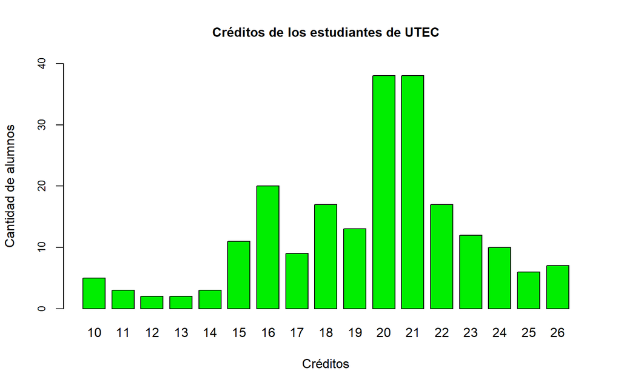

#### **Gráfico de barras 2**

Mediante este gráfico lograremos conocer la cantidad de estudiantes que consideran que la temperatura influye en su rendimiento académico, esta representación nos ayuda a identificar uno de los factores negativos del cambio de modalidad.

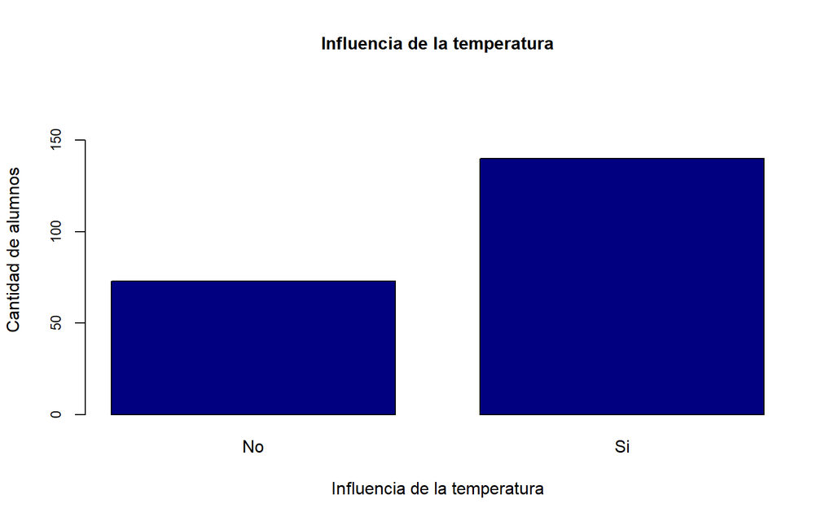

#### **Gráfico de barras 3**

Mediante esta gráfica lograremos conocer sobre la gran variedad de horas de estudio que tienen los estudiantes de UTEC y el cómo esto influye en su rendimiento académico.

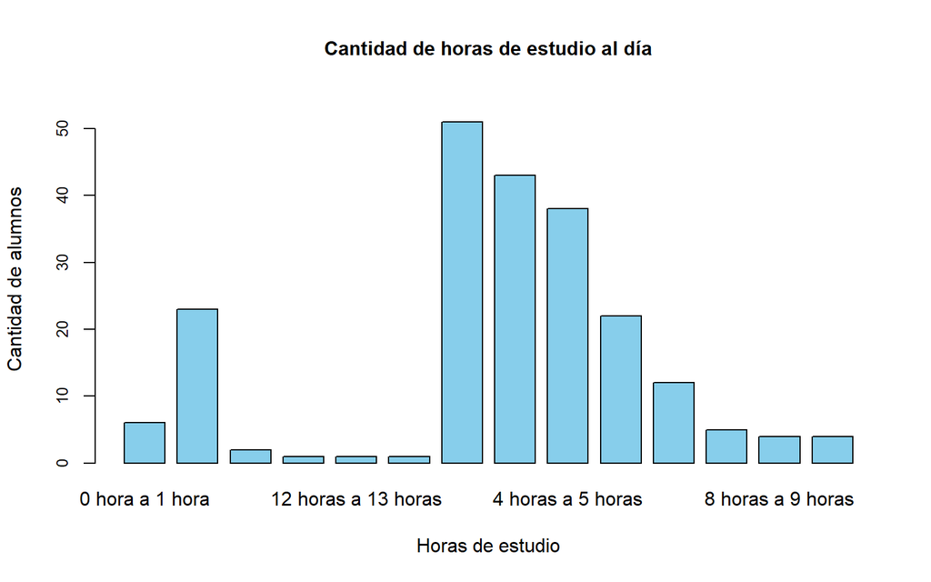

La mayoría de estudiantes estudia una cantidad relativa de horas, por lo que su desempeño en los estudios va a ser relativo.

#### **Gráfico de dispersión 1**

Mediante este gráfico lograremos identificar la clase más temprana de estudiante universitario en relación con las horas diarias de dormir.

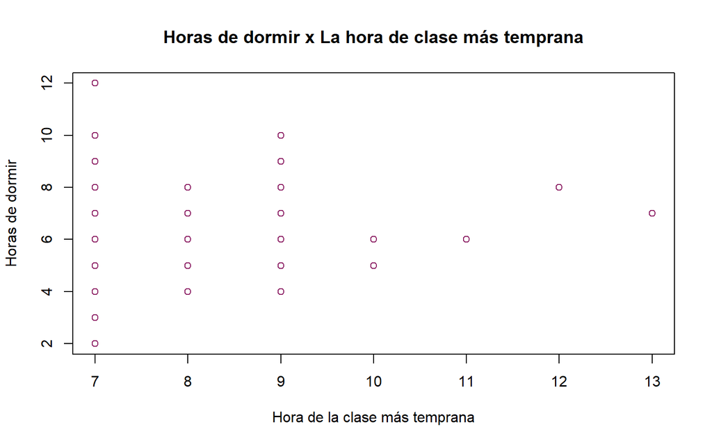

El gráfico nos indica que no hay relación entre las horas de dormir y la clase más temprana.

#### **Diagrama de dispersión 2**

Mediante este gráfico lograremos identificar el nivel de estrés del estudiante universitario en relación con la hora de clase más tarde que tiene en el día.

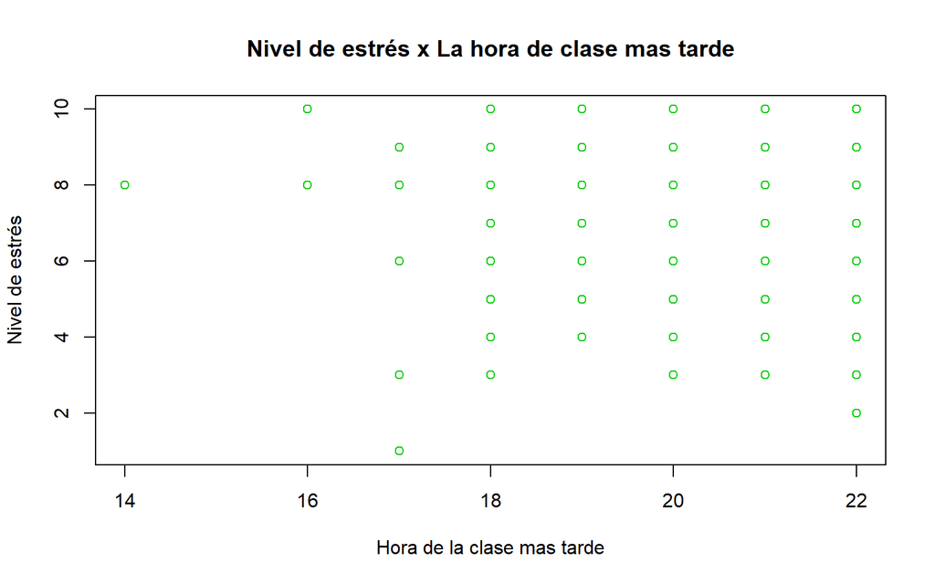

#### **Gráfico de caja 1**

Mediante esta gráfica lograremos identificar el cómo influye el tiempo de llegada a la universidad con respecto al nivel de estrés del estudiante universitario.

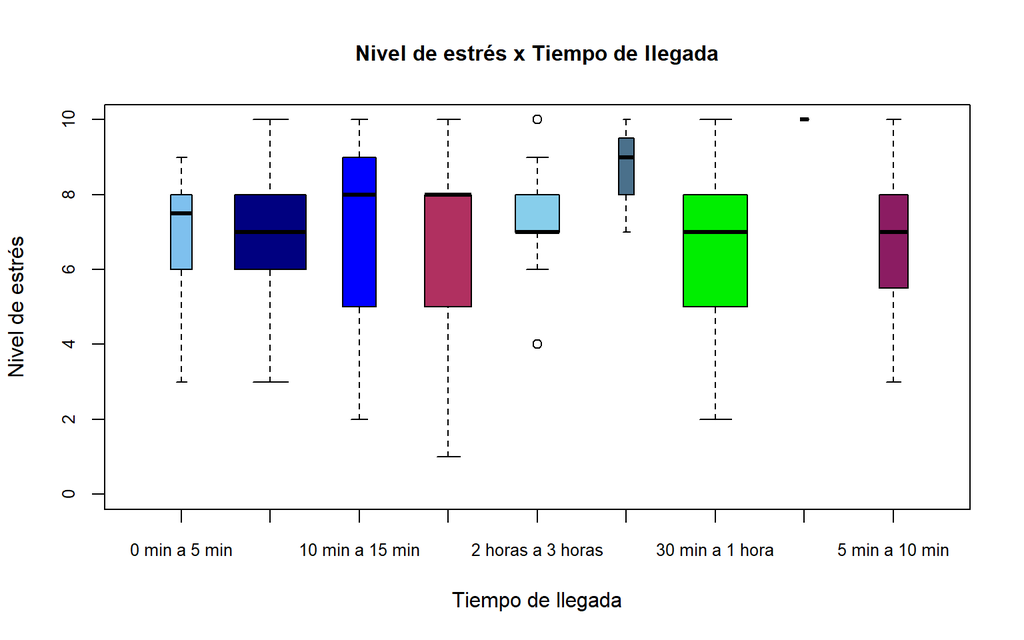

#### **Mosaico 1**

Mediante esta gráfica lograremos conocer como la percepción de seguridad es un factor para la preferencia de modalidad, debido a que si la zona en donde viven no es segura, se inclinarán a preferir una modalidad híbrida.

[figure not shown]

#### **Diagrama de caja 2**

Mediante esta gráfica lograremos observar la relación entre los gastos mensuales entre estudiantes que trabajan y los que no, en relación con la nueva modalidad presencial actual.

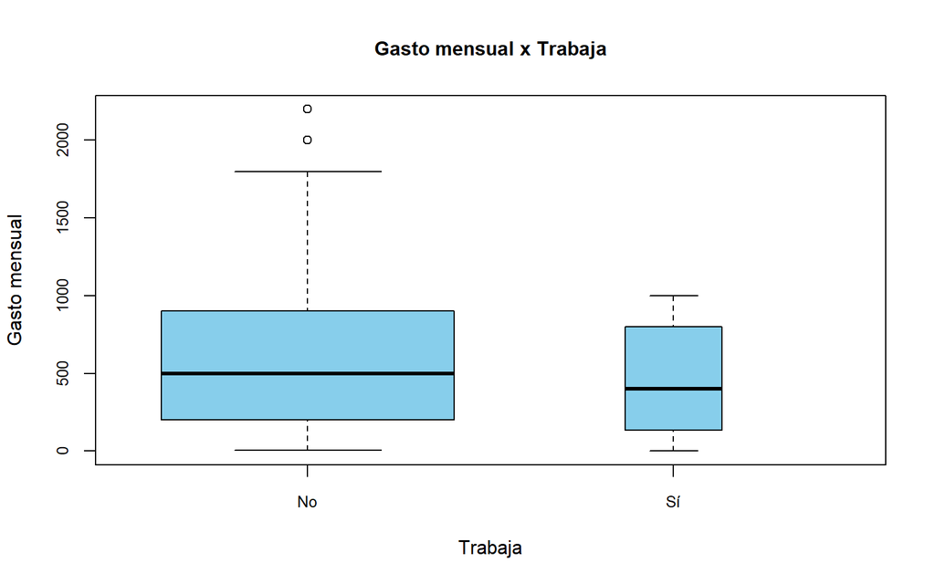

#### **Diagrama de caja 3**

Mediante este gráfico lograremos conocer la relación que existe entre la cantidad de créditos cursados por estudiantes que trabajan, y estudiantes que no.

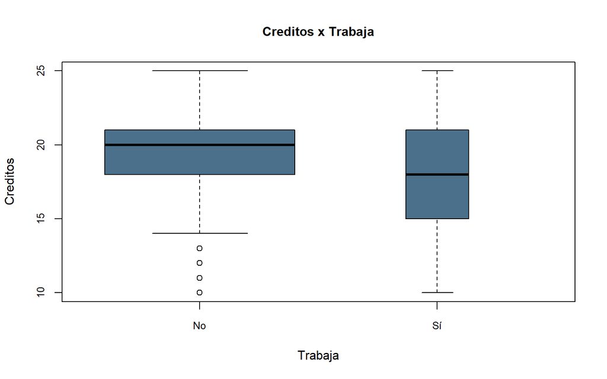

#### **Mosaico 2**

Mediante este gráfico lograremos conocer el cómo la influencia de la temperatura es un factor que lograría generar estrés junto a la presencialidad.

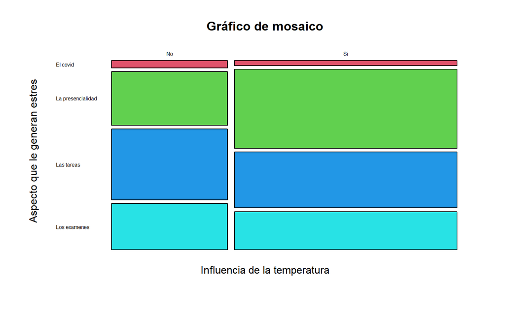

#### **Mosaico 3**

Mediante este gráfico lograremos identificar la preferencia de modalidad de los estudiantes en relación con el cambio de estudio, esto con el fin de poder recopilar información de como estos factores afectarían a su rendimiento académico.

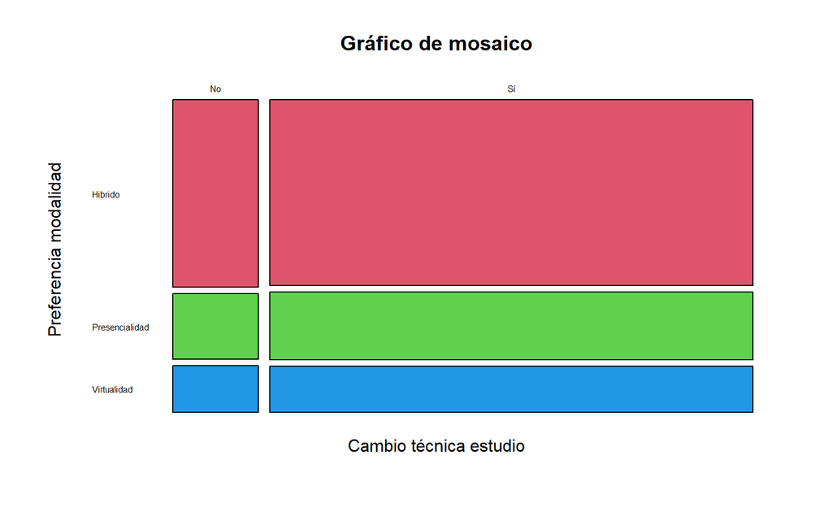

#### **Diagrama de caja 4**

Mediante este gráfico lograremos conocer la relación que existe entre la la percepción del nivel de estrés por el tiempo de llegar a la universidad en horas.

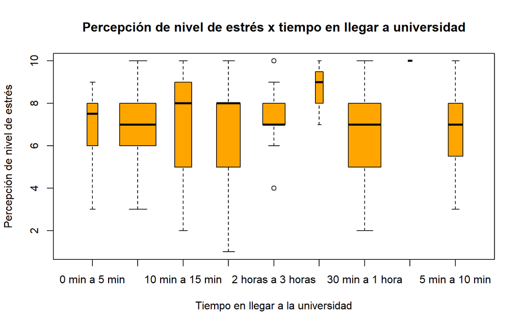

#### **Mosaico 4**

Mediante este gráfico lograremos identificar la percepción de los estudiantes de UTEC acerca de su desempeño académico por la preferencia de la modalidad, esto con el fin de poder recopilar información de como estos factores afectarían a su rendimiento académico.

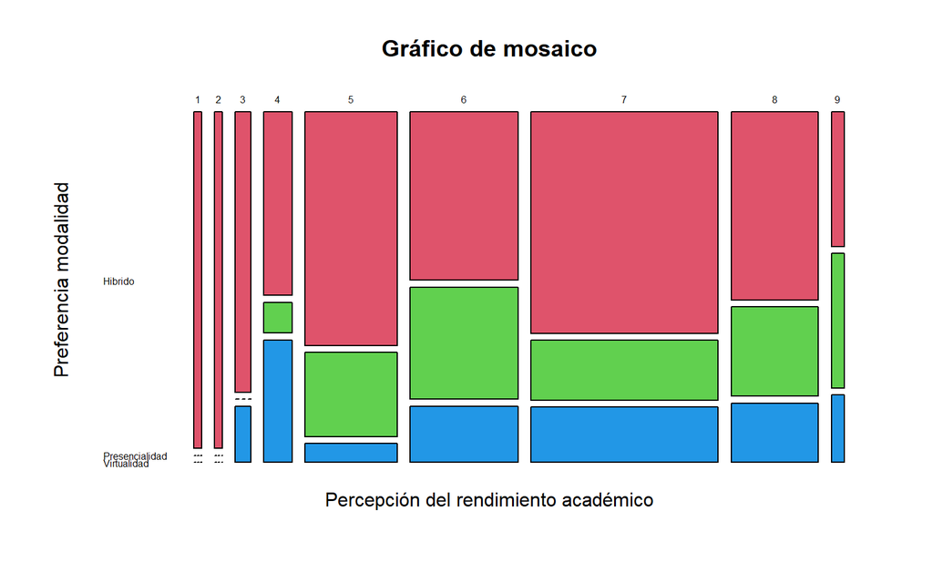

#### **Mosaico 5**

Mediante este gráfico lograremos identificar si el estudiante cambió o no sus técnicas de estudios por su percepción de como es su despeño académico hasta la fecha, esto con el fin de poder recopilar información de como estos factores afectarían a su rendimiento académico.

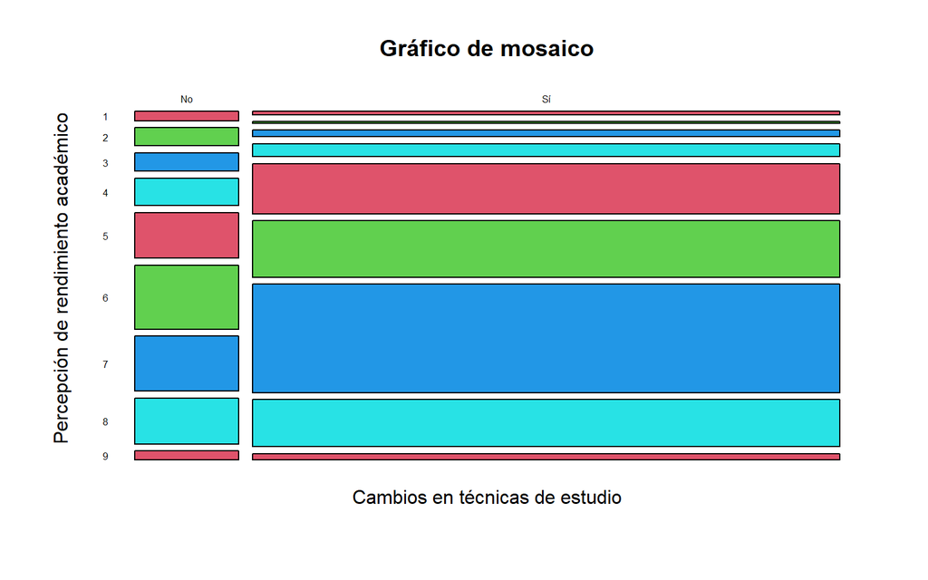